# Modeling and Predicting YouTube Engagement

INFO 523 - Final Project

This project analyzes YouTube video metadata such as title, category, and publish time to explore their impact on engagement metrics like views, likes, and comments. The goal is to uncover patterns that help explain why certain videos trend or perform better.

Author

Affiliation

Ashok kumar Marimuthu

College of Information Science, University of Arizona

# Abstract

With millions of videos uploaded to YouTube daily, understanding what drives viewer engagement is essential for content creators. This project explores how key video attributes such as title wording, category, upload timing, and video duration influence engagement metrics like views, likes, and comments. Using a dataset of trending videos from India, the analysis focuses on uncovering patterns and predictors associated with higher performance. The goal is to generate actionable insights that support content strategy for new and growing channels. These findings will also help inform the early direction of a future educational YouTube channel and a creator-focused analytics concept currently in development.

# Introduction

Understanding what drives viewer interaction including views, likes, and comments has become crucial for content success. In this project, we explore how video metadata such as title length, upload timing, video duration, and like ratio correlate with viewer engagement.

Our goal is twofold:

- To uncover key patterns and features that influence a video’s performance.
- To build predictive models that classify whether a video is likely to receive high engagement.

Using a combination of exploratory data analysis and machine learning models like Logistic Regression, Decision Tree, and Random Forest, we identify which factors matter most. The findings can support creators, marketers, and data-driven platforms in optimizing video content strategies.

# Research Questions

1. Which video attributes most influence engagement on YouTube?
2. Can we predict whether a video will achieve high engagement using metadata alone?
3. Which model performs best in predicting high engagement?

```
Shape: (251277, 16)
<class 'pandas.core.frame.DataFrame'>
RangeIndex: 251277 entries, 0 to 251276
Data columns (total 16 columns):
 #   Column             Non-Null Count   Dtype
---  ------             --------------   -----
 0   video_id           251277 non-null  object
 1   title              251277 non-null  object
 2   publishedAt        251277 non-null  object
 3   channelId          251277 non-null  object
 4   channelTitle       251276 non-null  object
 5   categoryId         251277 non-null  int64
 6   trending_date      251277 non-null  object
 7   tags               251277 non-null  object
 8   view_count         251277 non-null  int64
 9   likes              251277 non-null  int64
 10  dislikes           251277 non-null  int64
 11  comment_count      251277 non-null  int64
 12  thumbnail_link     251277 non-null  object
 13  comments_disabled  251277 non-null  bool
 14  ratings_disabled   251277 non-null  bool
 15  description        231822 non-null  object
dtypes: bool(2), int64(5), object(9)
memory usage: 27.3+ MB
```

|  | video_id | title | publishedAt | channelId | channelTitle | categoryId | trending_date | tags | view_count | likes | dislikes | comment_count | thumbnail_link | comments_disabled | ratings_disabled | description |
| --- | --- | --- | --- | --- | --- | --- | --- | --- | --- | --- | --- | --- | --- | --- | --- | --- |
| 0 | Iot0eF6EoNA | Sadak 2 \| Official Trailer \| Sanjay \| Pooja \| ... | 2020-08-12T04:31:41Z | UCGqvJPRcv7aVFun-eTsatcA | FoxStarHindi | 24 | 2020-08-12T00:00:00Z | sadak\|sadak 2\|mahesh bhatt\|vishesh films\|pooja... | 9885899 | 224925 | 3979409 | 350210 | https://i.ytimg.com/vi/Iot0eF6EoNA/default.jpg | False | False | Three Streams. Three Stories. One Journey. Sta... |
| 1 | x-KbnJ9fvJc | Kya Baat Aa : Karan Aujla (Official Video) Tan... | 2020-08-11T09:00:11Z | UCm9SZAl03Rev9sFwloCdz1g | Rehaan Records | 10 | 2020-08-12T00:00:00Z | [None] | 11308046 | 655450 | 33242 | 405146 | https://i.ytimg.com/vi/x-KbnJ9fvJc/default.jpg | False | False | Singer/Lyrics: Karan Aujla Feat Tania Music/ D... |
| 2 | KX06ksuS6Xo | Diljit Dosanjh: CLASH (Official) Music Video \|... | 2020-08-11T07:30:02Z | UCZRdNleCgW-BGUJf-bbjzQg | Diljit Dosanjh | 10 | 2020-08-12T00:00:00Z | clash diljit dosanjh\|diljit dosanjh\|diljit dos... | 9140911 | 296533 | 6179 | 30058 | https://i.ytimg.com/vi/KX06ksuS6Xo/default.jpg | False | False | CLASH official music video performed by DILJIT... |

# Feature Engineering

|  | title_length | upload_hour | like_ratio | trending_days |
| --- | --- | --- | --- | --- |
| count | 251277.000000 | 251277.000000 | 251261.000000 | 251277.000000 |
| mean | 70.158439 | 14.336493 | 0.053751 | 1.535469 |
| std | 23.882728 | 4.801789 | 0.042565 | 1.652290 |
| min | 2.000000 | 0.000000 | 0.000000 | -1.000000 |
| 25% | 51.000000 | 11.000000 | 0.020000 | 0.000000 |
| 50% | 73.000000 | 14.000000 | 0.040000 | 1.000000 |
| 75% | 93.000000 | 18.000000 | 0.080000 | 2.000000 |
| max | 100.000000 | 23.000000 | 0.640000 | 30.000000 |

To enhance predictive power and capture relevant video characteristics, we engineered the following features:

- title_length: Character count of the video title
- upload_hour: Hour of the day (0–23) extracted from the publishedAt timestamp
- like_ratio: Ratio of likes to views, a proxy for viewer satisfaction
- trending_days: Difference in days between publishedAt and trending_date, showing how quickly a video started trending

These features were chosen based on domain intuition:

- Upload timing may influence discoverability
- Title length might affect click-through rate
- Like ratio reflects audience sentiment
- Trending delay captures video momentum

All features were checked for valid data before creation, and invalid or infinite values were handled appropriately.

## Predicting Category Description

The source dataset doesn’t include category descriptions, only numerical category IDs. To generate meaningful insights on views by category, I’m mapping these IDs to their actual category names using available information from video titles and descriptions.

[output not shown]

```
Unique category IDs: 15
Sample category IDs: [np.int64(1), np.int64(2), np.int64(10), np.int64(15), np.int64(17), np.int64(19), np.int64(20), np.int64(22), np.int64(23), np.int64(24), np.int64(25), np.int64(26), np.int64(27), np.int64(28), np.int64(29)]

Unique inferred categories: 10
Inferred categories: ['Entertainment' 'Music' 'Other' 'People & Blogs' 'Gaming' 'Technology'
 'News' 'Sports' 'Comedy' 'Howto & Style']
       categoryId category_name
29              1         Other
136             2         Other
1              10         Music
51735          15         Other
19             17         Other
234            19         Other
5              20         Other
12             22         Other
10             23         Other
0              24         Other
15             25          News
30             26         Other
100            27         Other
70             28         Other
1698           29         Other
```

However, this approach often yields multiple category names for the same category ID, leading to inconsistencies. So I’m now taking a different approach by manually mapping category IDs based on patterns observed in sample videos.

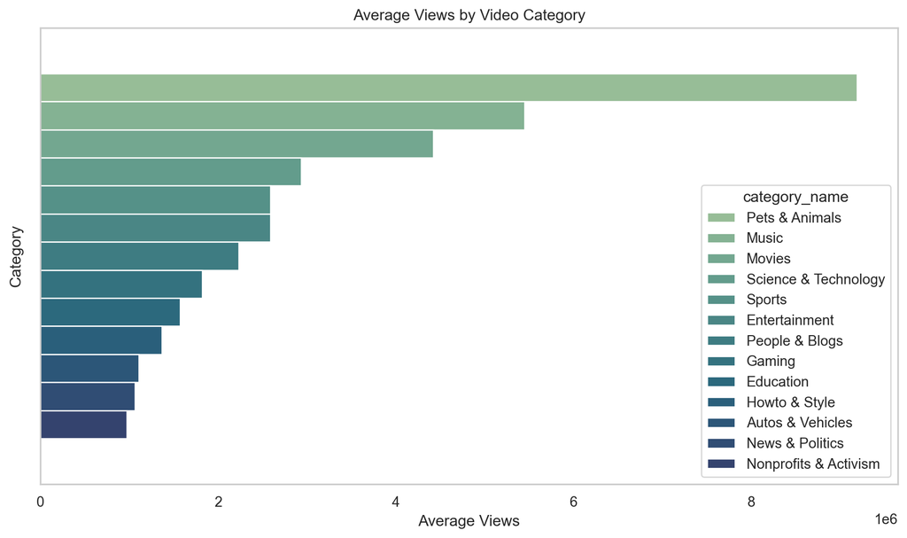

### Average Views by Category – Key Insight

To make the analysis interpretable, we first mapped each categoryId to a meaningful label using a combination of:

- Sample title and tag reviews from 1,000 randomly selected records
- Heuristic keyword matching
- Manual verification using known YouTube content types

This mapping allowed us to group videos into intuitive categories like Music, Entertainment, Gaming, and Howto & Style.

We then examined the average view count across these categories to understand what type of content resonates most with viewers in India.

The analysis revealed that:

- Pets & Animals and Music lead with the highest average views, showing strong emotional and entertainment appeal.
- Movies, Science & Technology, and Sports also perform well, suggesting high engagement with trailers, tech demos, and events.
- On the lower end, News & Politics and Nonprofits & Activism have lower average views, possibly due to niche audience interest or less viral potential.

This insight helps identify which content types are more likely to trend useful for both content creators and recommendation systems aiming to boost visibility.

# Exploratory Data Analysis

## Analyzing Missing Values:

```
                   missing_count  missing_percent
description                19455             7.74
video_id                       0             0.00
publishedAt                    0             0.00
title                          0             0.00
channelTitle                   1             0.00
categoryId                     0             0.00
trending_date                  0             0.00
channelId                      0             0.00
tags                           0             0.00
view_count                     0             0.00
dislikes                       0             0.00
likes                          0             0.00
comment_count                  0             0.00
thumbnail_link                 0             0.00
comments_disabled              0             0.00
ratings_disabled               0             0.00
```

Before creating new features, we examined the dataset for missing values:

The dataset contains 251,277 rows and 16 columns

- Most columns had no missing data
- The only column with significant missingness was description (7.74% missing), a non-critical text field not used in modeling
- One record had a missing channelTitle, which is negligible

**Conclusion:** Since all relevant columns for feature engineering (e.g., title, publishedAt, view_count, likes) were complete, we proceeded without any imputation or row removal.

## Impact of Upload Time (IST) on Average Views

Analyzing the influence of upload time on the trending videos.

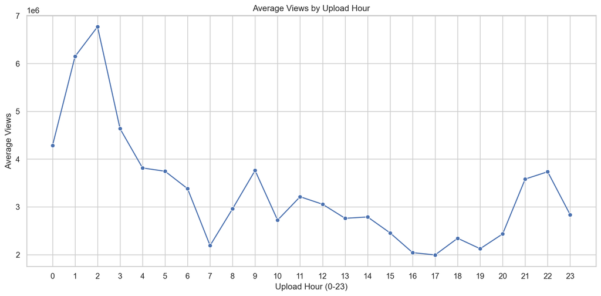

### Average Views by Upload Hour - Key Insight

After converting the publishedAt timestamps from UTC to Indian Standard Time (IST), we analyzed how the upload hour influences view counts.

This insight highlights the importance of timing for content release , especially for creators looking to maximize visibility and engagement in the Indian YouTube ecosystem.

## Impact of Title Length on View Count

Analyzing the impact of title length on the view count.

[figure not shown]

### Average Views by Title Length - Key Insights

To reduce noise from outliers, we grouped video titles into bins based on character count:

- 0–30
- 31–60
- 61–90
- 91–120

The analysis shows that:

- Titles with 61–90 characters had the highest average views
- Very short (0–30) and moderately short (31–60) titles had lower performance
- This suggests that moderate-to-long titles may be more effective at attracting clicks and generating views, possibly because they provide more context or keywords

While title length alone isn’t a perfect predictor of success, this pattern highlights the importance of well-optimized, descriptive titles in YouTube content strategy.

## Correlation Analysis

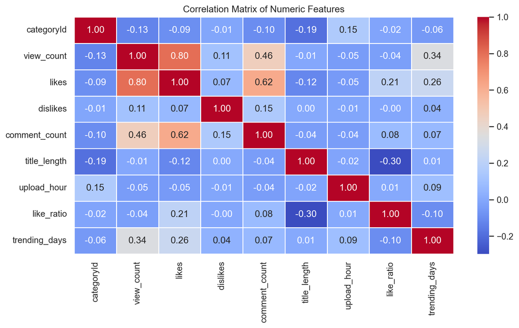

### Correlation Analysis - Key Insights

We computed the Pearson correlation coefficients between all numeric features in the dataset. Key insights:

- view_count has strong positive correlation with likes (0.80) and moderate correlation with comment_count (0.46).More likes and comments are naturally associated with higher views.
- likes and comment_count also have a moderate correlation (0.62), suggesting videos that get liked also tend to receive more comments.
- dislikes, title_length, upload_hour, and like_ratio show very weak or negligible correlation with view_count, indicating these may not be strong linear predictors.
- trending_days has a small positive correlation with view_count (0.34), possibly because videos that trend longer accumulate more views though causality can go either way.

**Conclusion:** While likes and comments are good indicators of engagement, some features like title length and upload hour may be more non-linear or contextual in their influence, which justifies using tree-based models that capture such interactions.

## Impact of Video Duration on View Count

As video duration is one of the key metrics influencing the view count but it’s not available in our primary data set, I am using the additional data fetched using the Youtube API to analyze this.

```
Saved file to /data/youtube_api_sample_with_duration.csv
```

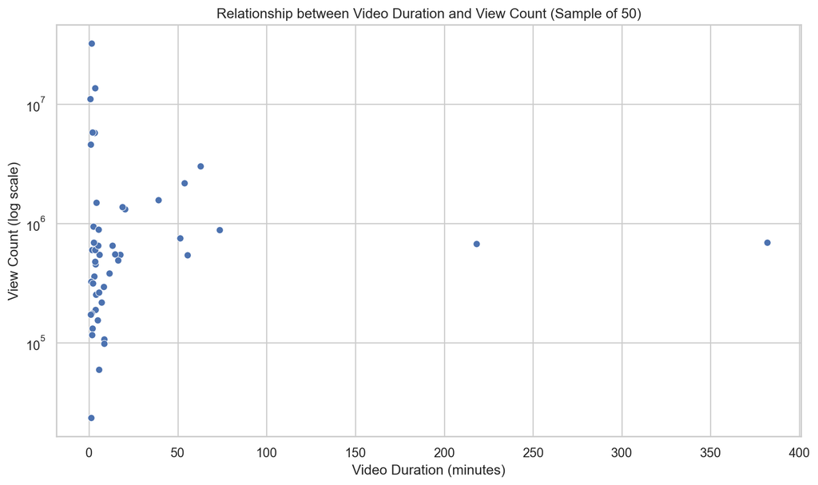

```
Average view count by duration category:
duration_bin
Short (<4 mins)       3.347441e+06
Long (10+ mins)       1.044555e+06
Medium (4-10 mins)    4.357051e+05
Name: viewCount, dtype: float64
```

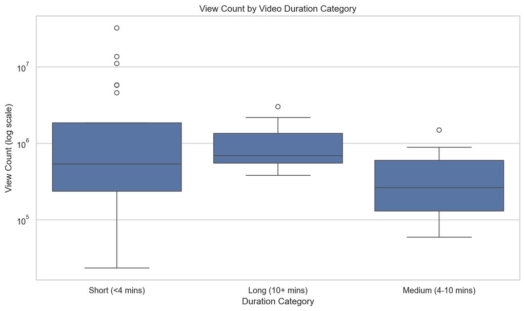

### Short videos (< 4 mins) had the highest average views

Despite the wider spread, they outperform medium and long videos on average.

While longer videos may offer more content, trending videos in our sample show a clear tilt toward shorter content. Videos under 4 minutes had the highest average views, possibly due to better retention and mobile-friendliness. This supports the rising popularity of short-form formats like YouTube Shorts and Reels.

# Target Variable & Class Proportions

We defined “High Performer” as the top 25% of videos by view count.

This creates a classification problem where: - 25% of videos are labeled High Performer (target = 1) - 75% are labeled Low Performer (target = 0)

This split was intentionally chosen to focus the model on identifying top-performing videos relative to the broader dataset.

```
Class Counts:
 high_performer
0    188457
1     62820
Name: count, dtype: int64

Class Percentage:
 high_performer
0    74.999702
1    25.000298
Name: proportion, dtype: float64
```

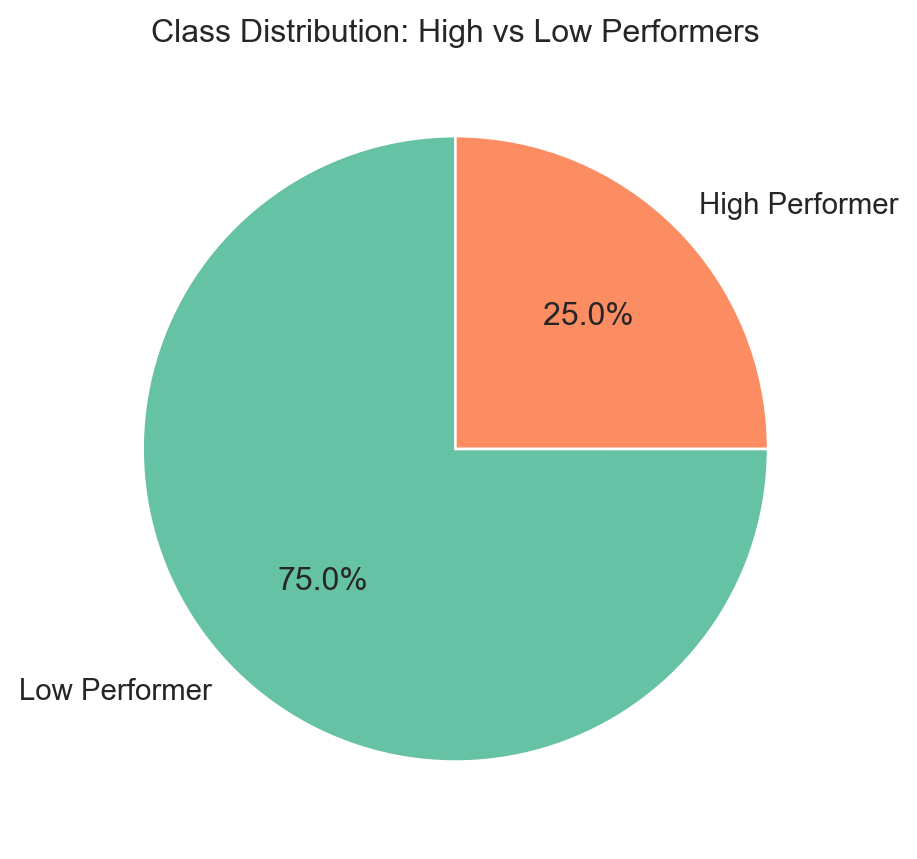

## Distribution of View Count

Analyzing the distribution of view count,

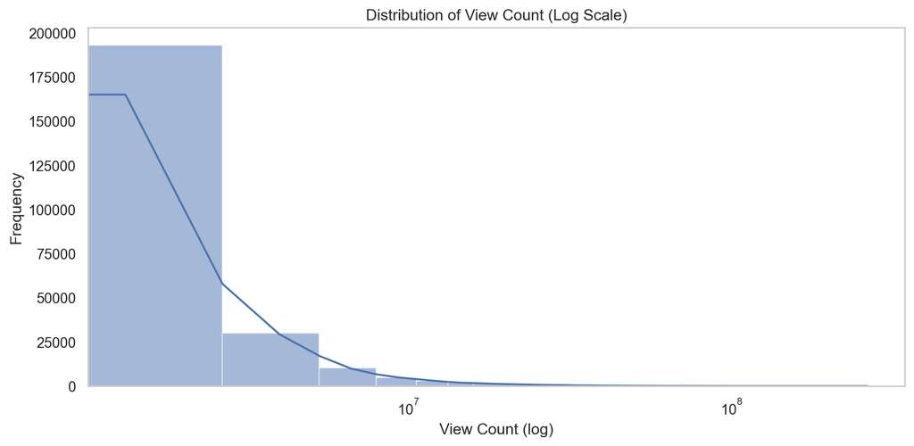

### Interpretation of View Count Distribution

To better understand the natural distribution of video popularity, we plotted the histogram of view_count on a log scale. The results show a highly right-skewed distribution, a small number of videos gain a disproportionately large number of views, while the majority have relatively low view counts.

This skew confirms the long-tail effect typical of platforms like YouTube, where a few viral videos dominate engagement. This justifies our choice to model the problem as a classification task by separating the top 25% (high performers) from the rest (low performers), rather than using raw view counts directly.

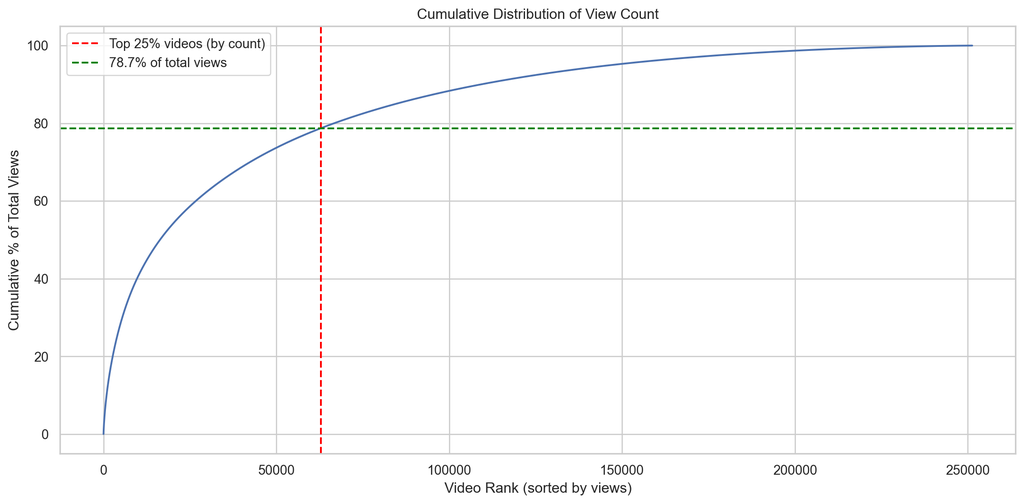

### Skewed Distribution of View Counts

To better understand how views are distributed across videos, we analyzed the cumulative view share by video rank.

# Modeling & Evaluation

## Model Training

```
Train shape: (175882, 16)
Test shape: (75379, 16)

--- Logistic Regression ---
              precision    recall  f1-score   support

           0       0.80      0.96      0.87     56533
           1       0.68      0.27      0.38     18846

    accuracy                           0.79     75379
   macro avg       0.74      0.61      0.63     75379
weighted avg       0.77      0.79      0.75     75379

ROC AUC: 0.7286

--- Decision Tree ---
              precision    recall  f1-score   support

           0       0.84      0.87      0.85     56533
           1       0.55      0.50      0.52     18846

    accuracy                           0.77     75379
   macro avg       0.70      0.68      0.69     75379
weighted avg       0.77      0.77      0.77     75379

ROC AUC: 0.7035

--- Random Forest ---
              precision    recall  f1-score   support

           0       0.84      0.89      0.87     56533
           1       0.61      0.51      0.55     18846

    accuracy                           0.80     75379
   macro avg       0.73      0.70      0.71     75379
weighted avg       0.79      0.80      0.79     75379

ROC AUC: 0.8007
```

## Hyper Parameter Tuning

We applied **Randomized Search** to efficiently explore a wide range of hyperparameters and identify the best combination for optimizing model performance.

```
Fitting 3 folds for each of 15 candidates, totalling 45 fits
Best Parameters: {'n_estimators': 200, 'min_samples_split': 2, 'min_samples_leaf': 4, 'max_features': 'sqrt', 'max_depth': 20, 'bootstrap': True}
              precision    recall  f1-score   support

           0       0.84      0.94      0.89     56533
           1       0.73      0.45      0.56     18846

    accuracy                           0.82     75379
   macro avg       0.78      0.70      0.72     75379
weighted avg       0.81      0.82      0.81     75379

ROC AUC Score: 0.8372980672977551
```

Trying the XGBoost model to see if there is a potential improvement with the AUC Score.

```
Fitting 3 folds for each of 10 candidates, totalling 30 fits
```

```
Best Params: {'subsample': 0.8, 'n_estimators': 200, 'max_depth': 7, 'learning_rate': 0.2, 'colsample_bytree': 0.8}
              precision    recall  f1-score   support

           0       0.90      0.80      0.84     56533
           1       0.55      0.74      0.63     18846

    accuracy                           0.78     75379
   macro avg       0.72      0.77      0.74     75379
weighted avg       0.81      0.78      0.79     75379

ROC AUC Score: 0.8523551979857035
```

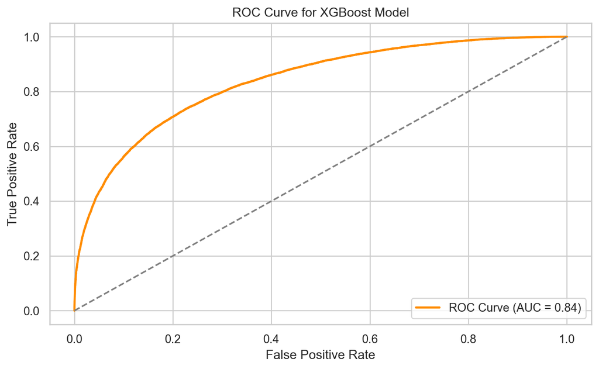

### ROC Curve for XGBoost Model - Interpretation

The ROC curve above illustrates the trade-off between the **true positive rate (sensitivity)** and **false positive rate** at various threshold settings for the XGBoost model.

## ROC Comparison

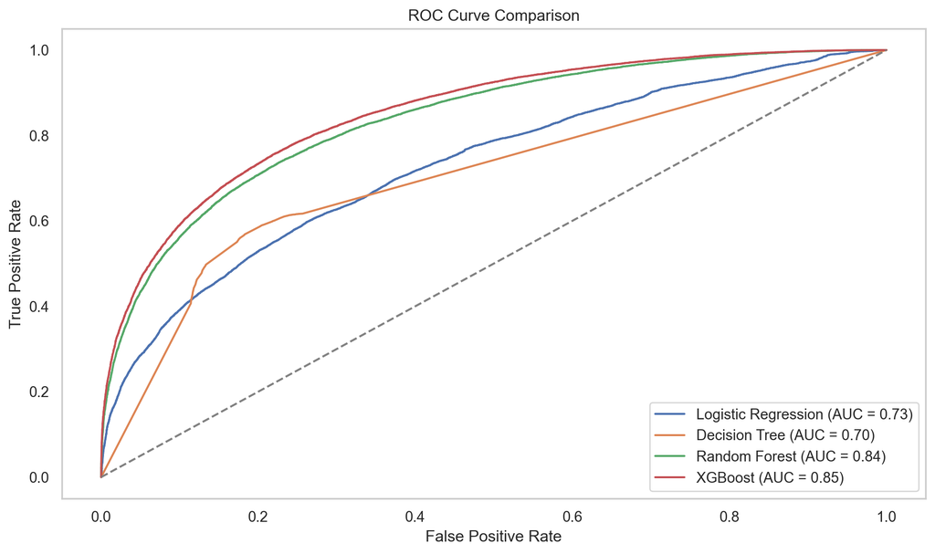

### ROC Curve Comparison – Model Performance

- This chart compares the performance of four classification models based on their ROC curves and AUC scores:
- **XGBoost** performs the best with an **AUC of 0.85**, indicating strong ability to distinguish between high and low engagement videos.
- **Random Forest** closely follows with an **AUC of 0.84**, also showing robust predictive power.
- **Logistic Regression** achieves an **AUC of 0.73**, offering a decent baseline but less nuanced decision boundaries.
- **Decision Tree** lags with an **AUC of 0.70**, likely due to overfitting and limited generalization.

  **Conclusion:** Ensemble models (Random Forest and XGBoost) clearly outperform simpler models by capturing complex patterns in the data, making them more effective for this classification task.

## Confusion Matrix

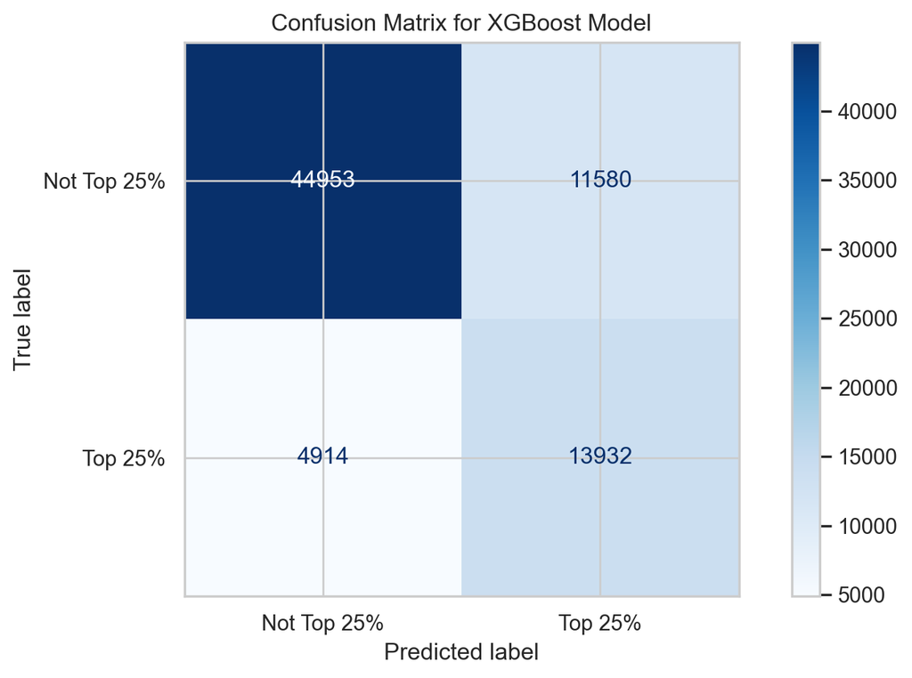

```
True Negatives: 44953
False Positives: 11580
False Negatives: 4914
True Positives: 13932
Precision: 0.55
Recall: 0.74
```

### Confusion Matrix - Key Insights

The confusion matrix shows the model performs well in identifying high-performing videos (Top 25%). While there are some false positives, the recall of 74% indicates the model captures the majority of true top performers. With a ROC AUC of 0.85, this XGBoost model is a strong candidate for helping creators or platforms prioritize videos with high viral potential.

## Feature Importance - XGBoost

To better understand what drives model predictions, we analyzed **feature importance scores from the XGBoost model**. These scores reflect how much each feature contributed to improving the model’s performance during training. Higher importance indicates a stronger influence on the final prediction of whether a video is a high performer.

This helps us not only interpret the model’s behavior but also identify which video attributes are most impactful for engagement.

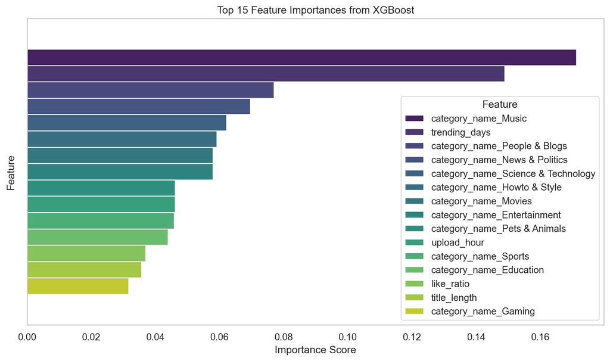

This plot suggests:

[output not shown]

# Conclusion & Next Steps

In this project, we explored how YouTube video metadata can be used to predict video engagement. After defining high-performing videos as those in the top 25% by views, we framed this as a binary classification problem and engineered features such as upload hour, title length, duration, and like ratio.

### Next Steps

- **Enhance feature set** by incorporating additional metadata such as tags, sentiment of the title, or channel subscriber count and audience demographics.
- **Personalize insights** by analyzing engagement patterns across different audiences or geographies.
- **Deploy the model** as a tool to help content creators optimize their upload strategy and video design choices.
- **Retrain periodically** using fresh data to adapt to evolving trends and platform algorithms.
- This work lays the foundation for a scalable, data-driven assistant that can support YouTube creators in making more strategic content decisions.